# R Notebook

Route 1. Selecting a dataset that requires extensive scraping or wrangling, and using at least one major analysis.

# Introduction

In the United States, overdose fatalities continue to be a major cause of injury-related mortality. Opioids are a prominent factor in most overdose fatalities. In recent years, the number of fatalities involving stimulants (such cocaine and methamphetamine) and synthetic opioids (like fentanyl produced illegally) has skyrocketed.

There are far more nonfatal drug overdoses than fatal ones, and each one has its own emotional and financial costs. A person is more likely to experience another overdose if they have already had one. When an overdose victim is evaluated in the ED, there is a chance to avoid a recurrent overdose by connecting the patient to treatment that can enhance their health outcomes.

Timely data help improve coordination and promote readiness among health departments, community members, healthcare providers, public health, law enforcement, and government agencies, for regional or multiple state overdose increases.

Procedures:

To better understand how different drug overdose impact on different groups of people,

First I would like to do EDA on the dataset to get general idea of the data such that what features are contained and how are they distributed.

Second, apply smoothing and regressionon the potential questions I am interested in:

- How are drugs overdoes deaths distributed in and related to gender, age, race, and time that he/she has dead?
- What drug causes the most death?
- Are the ages of death correlated to date? In other words, does the distribution of age for the death change over time?

# EDA and data processing

```r
#load packages
library(tidyr)
library(tidyverse)
library(data.table)
library(caret)
library(ggplot2)
library(dplyr)
library(skimr)
library(lubridate)
library(janitor)
library(scales)
library(ggrepel)
library(tidytext)
library(viridis)
```

```r
#load data
df <- read.csv("drug_deaths.csv")
df %>% summary()
```

```
       X             ID                Date              DateType          Age
 Min.   :   0   Length:5105        Length:5105        Min.   :0.000   Min.   :14.00
 1st Qu.:1276   Class :character   Class :character   1st Qu.:0.000   1st Qu.:32.00
 Median :2552   Mode  :character   Mode  :character   Median :0.000   Median :42.00
 Mean   :2552                                         Mean   :0.447   Mean   :41.96
 3rd Qu.:3828                                         3rd Qu.:1.000   3rd Qu.:52.00
 Max.   :5104                                         Max.   :1.000   Max.   :87.00
                                                      NA's   :2       NA's   :3
     Sex                Race           ResidenceCity      ResidenceCounty    ResidenceState
 Length:5105        Length:5105        Length:5105        Length:5105        Length:5105
 Class :character   Class :character   Class :character   Class :character   Class :character
 Mode  :character   Mode  :character   Mode  :character   Mode  :character   Mode  :character




  DeathCity         DeathCounty          Location         LocationifOther    DescriptionofInjury
 Length:5105        Length:5105        Length:5105        Length:5105        Length:5105
 Class :character   Class :character   Class :character   Class :character   Class :character
 Mode  :character   Mode  :character   Mode  :character   Mode  :character   Mode  :character




 InjuryPlace         InjuryCity        InjuryCounty       InjuryState            COD
 Length:5105        Length:5105        Length:5105        Length:5105        Length:5105
 Class :character   Class :character   Class :character   Class :character   Class :character
 Mode  :character   Mode  :character   Mode  :character   Mode  :character   Mode  :character




 OtherSignifican        Heroin          Cocaine         Fentanyl         Fentanyl_Analogue
 Length:5105        Min.   :0.0000   Min.   :0.0000   Length:5105        Min.   :0.0000
 Class :character   1st Qu.:0.0000   1st Qu.:0.0000   Class :character   1st Qu.:0.0000
 Mode  :character   Median :0.0000   Median :0.0000   Mode  :character   Median :0.0000
                    Mean   :0.4954   Mean   :0.2979                      Mean   :0.0762
                    3rd Qu.:1.0000   3rd Qu.:1.0000                      3rd Qu.:0.0000
                    Max.   :1.0000   Max.   :1.0000                      Max.   :1.0000

```

[output cut: 13 more lines]

```
 3rd Qu.:0.00000   3rd Qu.:0.00000   3rd Qu.:0.00000                      3rd Qu.:0.000000
 Max.   :1.00000   Max.   :1.00000   Max.   :1.00000                      Max.   :1.000000

    Other             OpiateNOS        AnyOpioid         MannerofDeath      DeathCityGeo
 Length:5105        Min.   :0.00000   Length:5105        Length:5105        Length:5105
 Class :character   1st Qu.:0.00000   Class :character   Class :character   Class :character
 Mode  :character   Median :0.00000   Mode  :character   Mode  :character   Mode  :character
                    Mean   :0.01724
                    3rd Qu.:0.00000
                    Max.   :1.00000

 ResidenceCityGeo   InjuryCityGeo
 Length:5105        Length:5105
 Class :character   Class :character
 Mode  :character   Mode  :character
```

```r
# How does the dataset look like
head(df)
```

|  | X | ID | Date | DateType | Age | Sex | Race | ResidenceCity | ResidenceCounty | ResidenceState | DeathCity | DeathCounty | Location | LocationifOther | DescriptionofInjury | InjuryPlace | InjuryCity | InjuryCounty | InjuryState | COD | OtherSignifican | Heroin | Cocaine | Fentanyl | Fentanyl_Analogue | Oxycodone | Oxymorphone | Ethanol | Hydrocodone | … |
| --- | --- | --- | --- | --- | --- | --- | --- | --- | --- | --- | --- | --- | --- | --- | --- | --- | --- | --- | --- | --- | --- | --- | --- | --- | --- | --- | --- | --- | --- | --- |
| 1 | 0 | 14-0273 | 06/28/2014 12:00:00 AM | 1 | NA |  |  |  |  |  |  |  |  |  | substance |  |  |  |  | Acute fent, hydrocod, benzodiazepine |  | 0 | 0 | 1 | 0 | 0 | 0 | 0 | 1 | … |
| 2 | 1 | 13-0102 | 03/21/2013 12:00:00 AM | 0 | 48 | Male | Black | NORWALK |  |  | NORWALK | FAIRFIELD | Hospital |  |  |  |  |  |  | Cocaine Intoxication |  | 0 | 1 | 0 | 0 | 0 | 0 | 0 | 0 | … |
| 3 | 2 | 16-0165 | 03/13/2016 12:00:00 AM | 0 | 30 | Female | White | SANDY HOOK | FAIRFIELD | CT | DANBURY |  | Hospital |  | Substance Abuse | Unknown | UNKNOWN |  |  | Acute Heroin and Cocaine Intoxication |  | 1 | 1 | 0 | 0 | 0 | 0 | 0 | 0 | … |
| 4 | 3 | 16-0208 | 03/31/2016 12:00:00 AM | 0 | 23 | Male | White | RYE | WESTCHESTER | NY | GREENWICH |  | Hospital |  | substance abuse | Residence | RYE |  |  | Acute Fentanyl and Morphine Intoxication |  | 1 | 0 | 1 | 0 | 0 | 0 | 0 | 0 | … |
| 5 | 4 | 13-0052 | 02/13/2013 12:00:00 AM | 0 | 22 | Male | Asian, Other | FLUSHING | QUEENS |  | GREENWICH | FAIRFIELD | Hospital |  | Transdermal Absorption | Other |  |  |  | Fentanyl Intoxication |  | 0 | 0 | 1 | 0 | 0 | 0 | 0 | 0 | … |
| 6 | 5 | 14-0277 | 06/29/2014 12:00:00 AM | 0 | 23 | Male | White | BRISTOL |  |  | BRISTOL | HARTFORD | Residence |  | Inhalation | Residence |  |  |  | Heroin Intoxication |  | 1 | 0 | 0 | 0 | 0 | 0 | 0 | 0 | … |

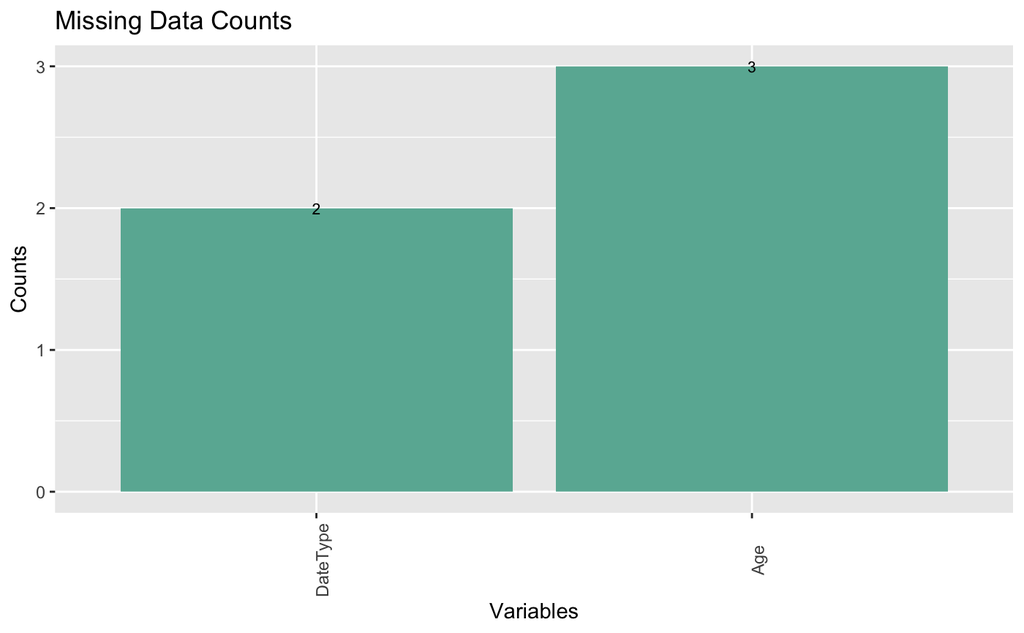

```r
#missing values?
df %>% skim() %>% filter(n_missing != 0) %>%
  ggplot(aes(x = reorder(skim_variable, n_missing), y = n_missing, label = n_missing) )+
  geom_col(fill="#69b3a2")+
  geom_text(size = 2.8, hjust = 0.5)+
  theme(legend.position = "none",axis.text.x = element_text(angle = 90))+
  labs(title = "Missing Data Counts",
       x = "Variables",
       y = "Counts"
  )
```

The problem is that there are many empty strings. Now It’s time to convert them to `NA`.

## missing values

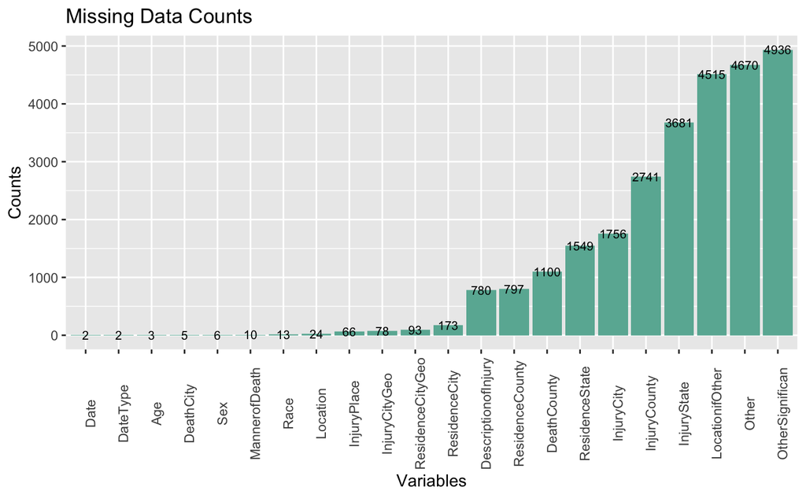

```r
#replace all empty strings with NA
df[df==""]<-NA

df %>% skim() %>% filter(n_missing != 0) %>%
  ggplot(aes(x = reorder(skim_variable, n_missing), y = n_missing, label = n_missing) )+
  geom_col(fill="#69b3a2")+
  geom_text(size = 2.8, hjust = 0.5)+
  theme(legend.position = "none",axis.text.x = element_text(angle = 90))+
  labs(title = "Missing Data Counts",
       x = "Variables",
       y = "Counts"
  )
```

After the EDA, I noticed there are a lot of missing data and the data is not quite clean as there are different ways to describe the same cause of death in the COD column, but essentially we are interested in the drug that cause the death. Also the some of the same values are written in both upper and lower cases. The drug variables are binary values which would be useful if they are combined in one column. Most NAs in this dataset were shown as empty string. I have converted them to NAs yet still a lot of them are missing. Fortunately the most of the nulls are not in the columns that I’m interested in regarding this study, so I would leave them there for the moment.

There are many columns mixed values in both upper and lowercases. It can be problem-causing when making graphs with `count`. Same value showing in different formats can be double-counted. I’m converting all strings in the dataset to uppercase.

`Date` column is formatted in “m-d-Y H:M:S”. For later time analysis, it would be easier to show only years in the strings. Here, I use lubridate package to extract year.

```r
df<-data.frame(lapply(df, function(v) {
  if (is.character(v)) return(toupper(v))
  else return(v)
}))
dates <- as.POSIXct(df$Date,format = "%m/%d/%Y %H:%M:%S", tz = "UTC")
df$Date<-year(dates)
```

## Visualizations

In order to get some general information out of the dataset, I am creating some visualization here.

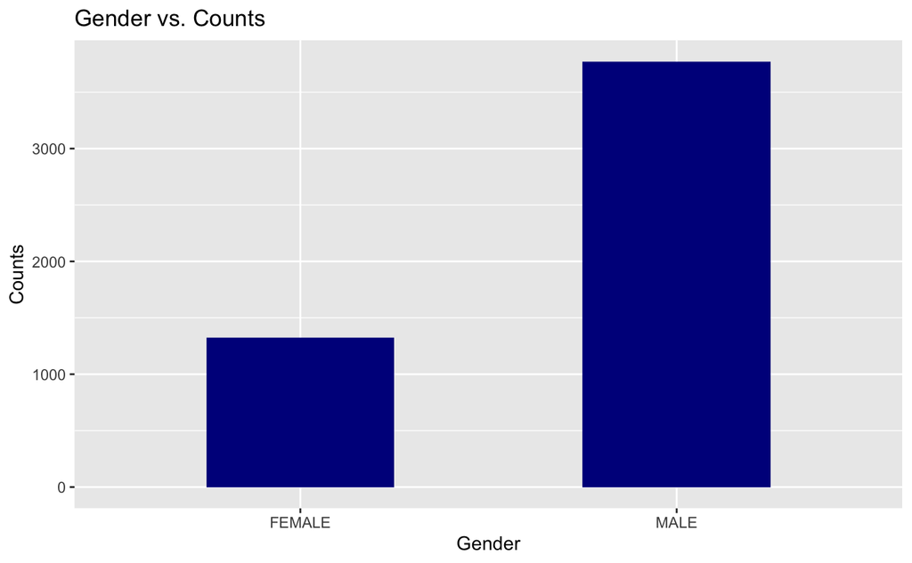

```r
#features with value count
# age, race, gender, cause of death
df%>% group_by(Sex)%>%filter(Sex!="UNKNOWN"&!is.na(Sex))%>%summarise(n=n())%>%ggplot(aes(x=Sex, y=n)) +
  geom_bar(stat="identity",fill="darkblue",width=0.5)+
  labs(title = "Gender vs. Counts",
       x = "Gender",
       y = "Counts"
  )
```

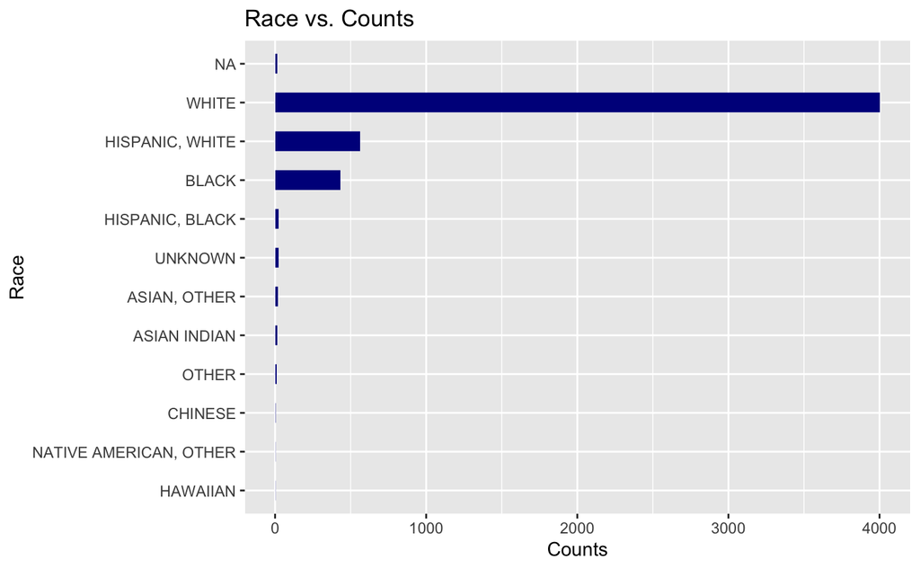

```r
df%>% group_by(Race)%>%summarise(n=n())%>%ggplot(aes(x=reorder(Race,n), y=n)) +
  geom_bar(stat="identity",fill="darkblue",width=0.5)+coord_flip()+
  labs(title = "Race vs. Counts",
       x = "Race",
       y = "Counts"
  )
```

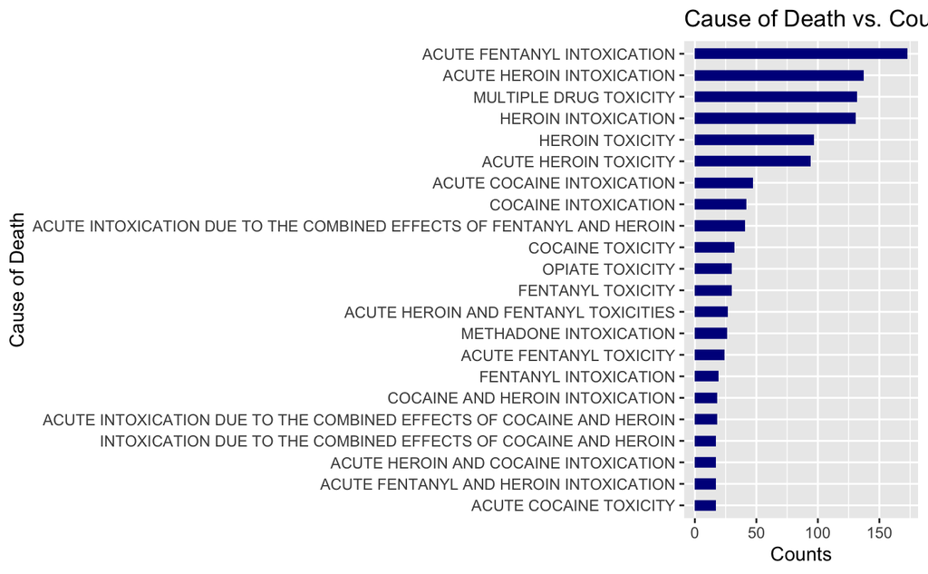

```r
cod<- df%>% group_by(COD)%>%summarise(count=n())%>%arrange(desc(count))
top_n(cod, n=20, count) %>%
          ggplot(., aes(x=reorder(COD,count), y=count))+
              geom_bar(stat='identity',fill="darkblue",width=0.5)+coord_flip()+
    labs(title = "Cause of Death vs. Counts",
       x = "Cause of Death",
       y = "Counts"
  )
```

```r
df<-df %>%
  mutate(
    # Create categories
    age_group = dplyr::case_when(
      Age <= 18            ~ "0-18",
      Age > 18 & Age <= 36 ~ "19-36",
      Age > 36 & Age <= 54 ~ "37-54",
      Age > 54 & Age <=72   ~ "55-72",
      Age >72 ~ ">72"
    ),
    age_group = factor(
      age_group,
      level = c("0-18", "19-36","37-54", "55-72",">72")
    )
  )
```

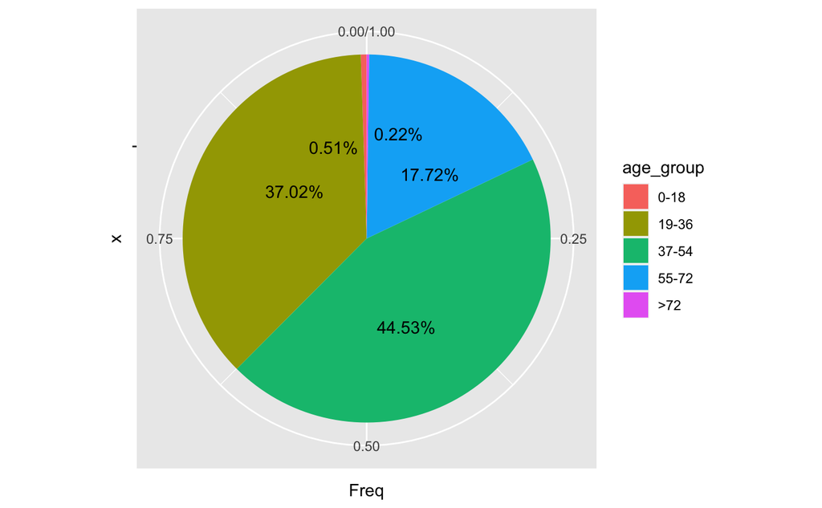

```r
age <- df %>%drop_na(age_group)%>%
  group_by(age_group) %>%
  summarise(n = n()) %>%
  mutate(Freq = n/sum(n)) %>%
  mutate(labels = scales::percent(Freq))

ggplot(age, aes(x = "", y = Freq, fill = age_group)) +
  geom_col() +
  geom_text_repel(aes(label = labels),
            position = position_stack(vjust = 0.5)) +
  coord_polar(theta = "y")
```

As graphs showing above, the deaths of males are tripled the death of females. Most objectives in the dataset are white or Hispanic white group. The top causes of death are acute fentanyl intoxication, acute herion intoxication, multiple drug toxicity, resulted from use of fentanyl, herion, and combination of different drugs. Surprisingly, the overdose death happened mostly among people in 37-54 age group, rather younger or the elderly groups.

Since the original dataset had each type of drug as columns(a wide dataset), I’m reshaping the dataset using pivot_longer to convert wide data into tidy data.

```r
df$Fentanyl <- as.numeric(as.character(df$Fentanyl))
df$Morphine_NotHeroin<-as.numeric(as.character(df$Morphine_NotHeroin))

df2 <- df %>% select("ID","Date","ResidenceState","Age","age_group","Race","Sex","COD","MannerofDeath","Location","Heroin","Fentanyl","Fentanyl_Analogue","Morphine_NotHeroin","Cocaine","Oxycodone","Oxymorphone","Ethanol","Hydrocodone","Benzodiazepine","Methadone","Amphet","Tramad","Hydromorphone") %>%
  pivot_longer(cols = c("Heroin","Fentanyl","Fentanyl_Analogue","Morphine_NotHeroin","Cocaine","Oxycodone","Oxymorphone","Ethanol","Hydrocodone","Benzodiazepine","Methadone","Amphet","Tramad","Hydromorphone"),
    names_to = "drug_name",
    values_to = "value",
    values_drop_na = TRUE)
df2<-data.frame(lapply(df2, function(v) {
  if (is.character(v)) return(toupper(v))
  else return(v)
}))
```

## Drugs that caused overdose death in female and male

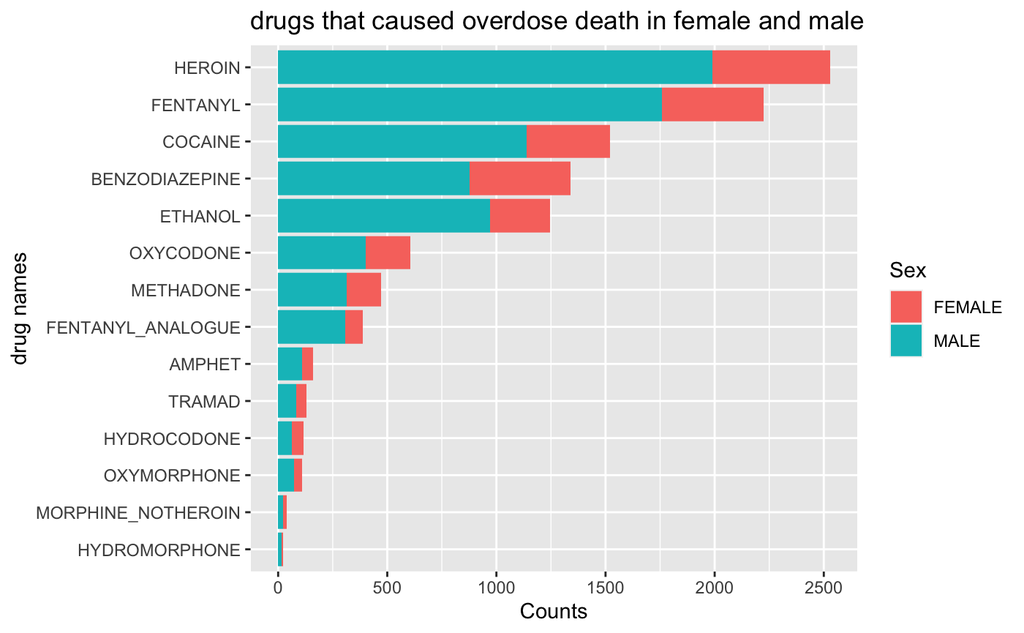

```r
df2 %>% filter(value != 0,Sex != "UNKNOWN", !is.na(Sex)) %>%
  group_by(drug_name, Sex) %>%
  summarise(Count = sum(value), .groups = "drop") %>%
  mutate(sum = sum(Count)) %>%
  ggplot(aes(x = reorder(drug_name, Count), y = Count, fill = Sex)) +
  geom_col()+
  coord_flip()+
  labs(title = "drugs that caused overdose death in female and male",
       x = "drug names",
       y = "Counts"
  )
```

From this graph, I learned that herion, fentanyl, cocaine, benzodiazepine, and ethanol are the top 5 drugs used among the dead.

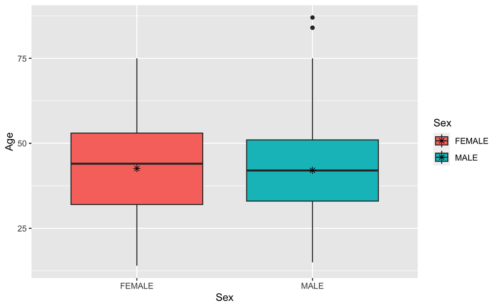

```r
df2 %>%
  filter(value != 0,
         Sex != "UNKNOWN",
         !is.na(Sex)) %>%
  ggplot(aes(x = Sex, y = Age, fill=Sex)) +
  geom_boxplot() +
  stat_summary(fun = "mean", geom = "point", shape = 8,
               size = 2, color = "black")
```

## Smoothing

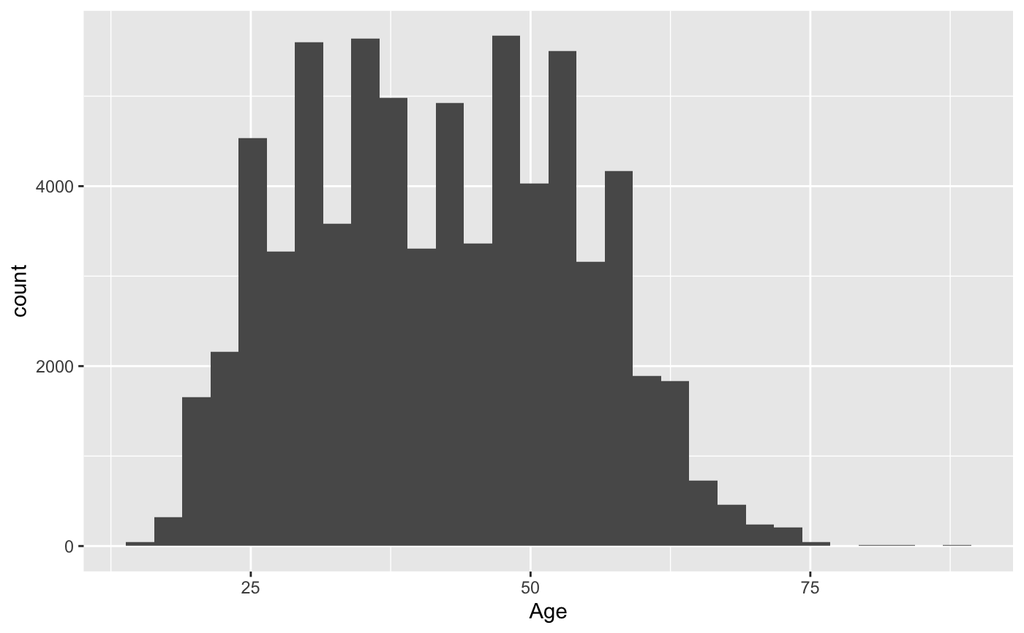

```r
df2%>%drop_na(Sex)%>%filter(Sex!="UNKNOWN")%>%ggplot(aes(Age)) +
  geom_histogram()
```

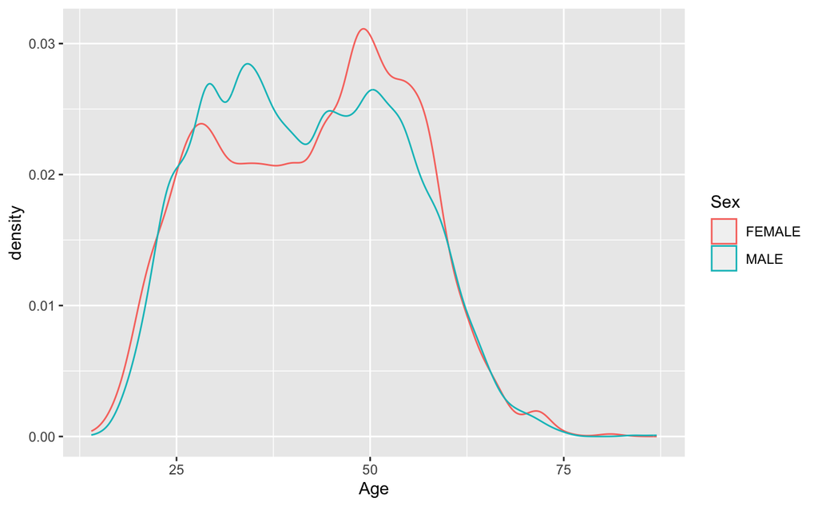

```r
#smoothed
df2%>%drop_na(Sex)%>%filter(Sex!="UNKNOWN")%>%ggplot(aes(Age,colour=Sex)) +
  geom_density()
```

Slightly difference in age distribution between female and male.

## how does overdose death changed over time

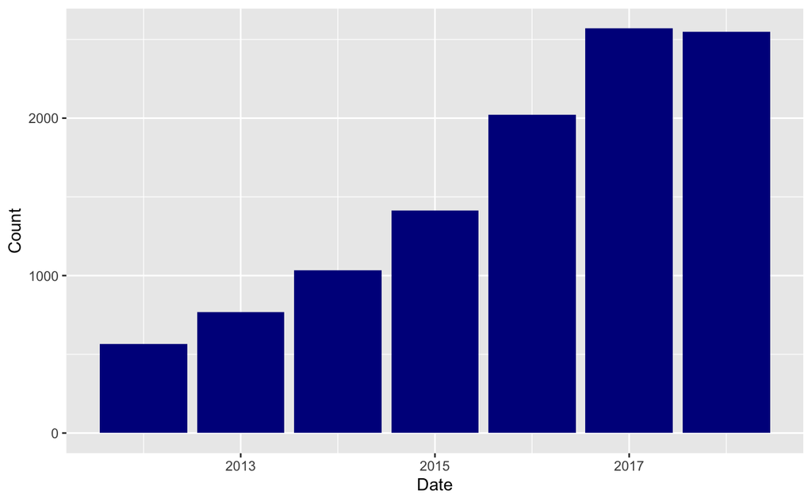

```r
df2 %>%
  filter(value != 0) %>%
  group_by(Date) %>%
  summarise(Count = n(), .groups = "drop") %>%
ggplot(aes(x = Date,y = Count)) +geom_col(fill="darkblue")
```

```r
try<-df%>%filter(Sex!="UNKNOWN")%>%drop_na(Age,Date,Sex)
rho <- mean(scale(try$Age) * scale(try$Date))
rho
```

```
[1] 0.03463926
```

The correlation coefficient is nearly 0.

What if we simulate it using Monte Carlo simulation? (Code adapted from chapter 17 Regression from http://rafalab.dfci.harvard.edu/dsbook/regression.html)

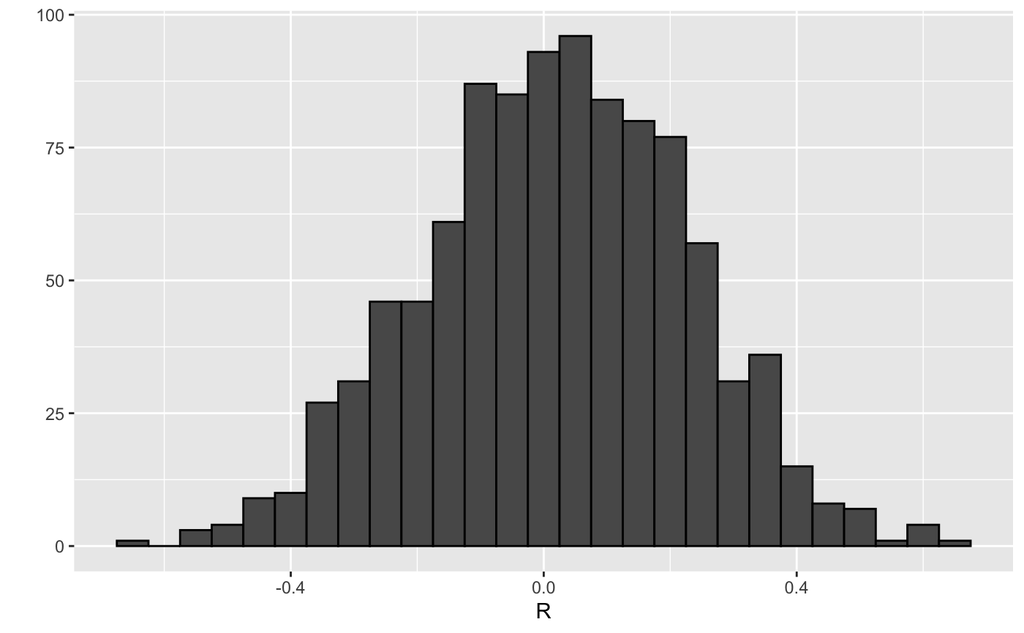

```r
R <- sample_n(try, 25, replace = TRUE) |>
  summarize(r = cor(Age, Date)) |> pull(r)
B <- 1000
N <- 25
R <- replicate(B, {
  sample_n(try, N, replace = TRUE) |>
    summarize(r=cor(Age, Date)) |>
    pull(r)
})
qplot(R, geom = "histogram", binwidth = 0.05, color = I("black"))
```

```r
mean(R)
```

```
[1] 0.01797985
```

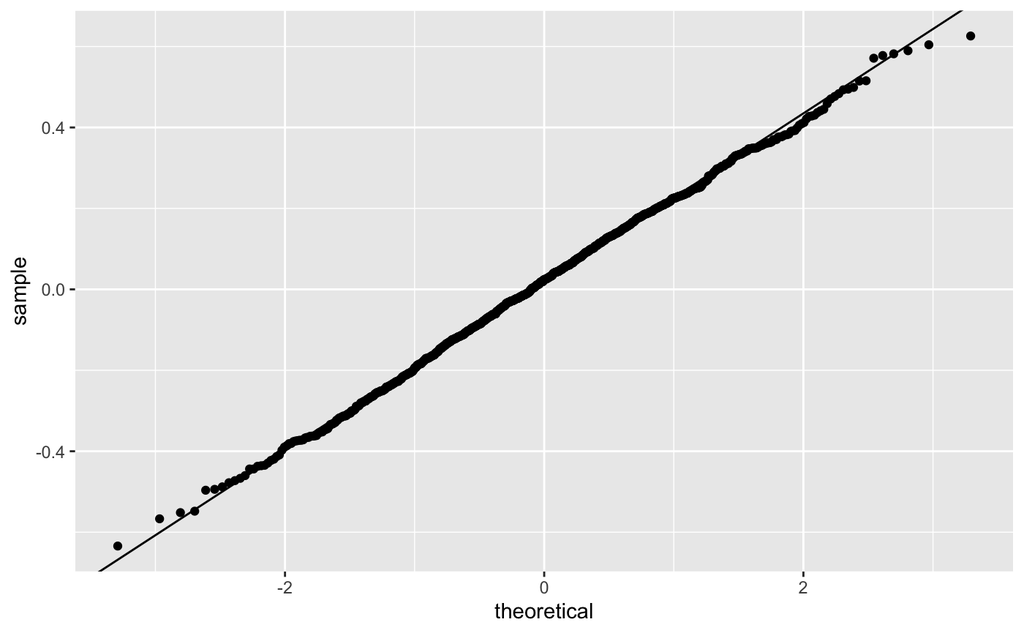

```r
ggplot(aes(sample=R), data = data.frame(R)) +
  stat_qq() +
  geom_abline(intercept = mean(R), slope = sqrt((1-mean(R)^2)/(N-2)))
```

The distribution is converging to normal but the correlation coefficient is still around 0. Correlation is not always a good summary of the relationship between `age` and `date`.

# Results

```r
#before and after
df
```

| X | ID | Date | DateType | Age | Sex | Race | ResidenceCity | ResidenceCounty | ResidenceState | DeathCity | DeathCounty | Location | LocationifOther | DescriptionofInjury | InjuryPlace | InjuryCity | InjuryCounty | InjuryState | COD | OtherSignifican | Heroin | Cocaine | Fentanyl | Fentanyl_Analogue | Oxycodone | Oxymorphone | Ethanol | Hydrocodone | Benzodiazepine | … |
| --- | --- | --- | --- | --- | --- | --- | --- | --- | --- | --- | --- | --- | --- | --- | --- | --- | --- | --- | --- | --- | --- | --- | --- | --- | --- | --- | --- | --- | --- | --- |
| 0 | 14-0273 | 2014 | 1 | NA | NA | NA | NA | NA | NA | NA | NA | NA | NA | SUBSTANCE | NA | NA | NA | NA | ACUTE FENT, HYDROCOD, BENZODIAZEPINE | NA | 0 | 0 | 1 | 0 | 0 | 0 | 0 | 1 | 1 | … |
| 1 | 13-0102 | 2013 | 0 | 48 | MALE | BLACK | NORWALK | NA | NA | NORWALK | FAIRFIELD | HOSPITAL | NA | NA | NA | NA | NA | NA | COCAINE INTOXICATION | NA | 0 | 1 | 0 | 0 | 0 | 0 | 0 | 0 | 0 | … |
| 2 | 16-0165 | 2016 | 0 | 30 | FEMALE | WHITE | SANDY HOOK | FAIRFIELD | CT | DANBURY | NA | HOSPITAL | NA | SUBSTANCE ABUSE | UNKNOWN | UNKNOWN | NA | NA | ACUTE HEROIN AND COCAINE INTOXICATION | NA | 1 | 1 | 0 | 0 | 0 | 0 | 0 | 0 | 0 | … |
| 3 | 16-0208 | 2016 | 0 | 23 | MALE | WHITE | RYE | WESTCHESTER | NY | GREENWICH | NA | HOSPITAL | NA | SUBSTANCE ABUSE | RESIDENCE | RYE | NA | NA | ACUTE FENTANYL AND MORPHINE INTOXICATION | NA | 1 | 0 | 1 | 0 | 0 | 0 | 0 | 0 | 0 | … |
| 4 | 13-0052 | 2013 | 0 | 22 | MALE | ASIAN, OTHER | FLUSHING | QUEENS | NA | GREENWICH | FAIRFIELD | HOSPITAL | NA | TRANSDERMAL ABSORPTION | OTHER | NA | NA | NA | FENTANYL INTOXICATION | NA | 0 | 0 | 1 | 0 | 0 | 0 | 0 | 0 | 0 | … |
| 5 | 14-0277 | 2014 | 0 | 23 | MALE | WHITE | BRISTOL | NA | NA | BRISTOL | HARTFORD | RESIDENCE | NA | INHALATION | RESIDENCE | NA | NA | NA | HEROIN INTOXICATION | NA | 1 | 0 | 0 | 0 | 0 | 0 | 0 | 0 | 0 | … |
| 6 | 12-0205 | 2012 | 0 | 21 | FEMALE | WHITE | WEST HARTFORD | HARTFORD | NA | WEST HARTFORD | HARTFORD | RESIDENCE | NA | USED HEROIN | RESIDENCE | NA | NA | NA | HEROIN TOXICITY | NA | 1 | 0 | 0 | 0 | 0 | 0 | 0 | 0 | 0 | … |
| 7 | 13-0404 | 2013 | 0 | 40 | FEMALE | WHITE | HAMDEN | NEW HAVEN | NA | NEW HAVEN | NEW HAVEN | HOSPITAL | NA | NA | NA | NA | NA | NA | COMPLICATIONS OF COCAINE INTOXICATION | NA | 0 | 1 | 0 | 0 | 0 | 0 | 0 | 0 | 0 | … |
| 8 | 12-0107 | 2012 | 0 | 40 | MALE | WHITE | EAST HARTFORD | HARTFORD | NA | EAST HARTFORD | HARTFORD | RESIDENCE | NA | USED HEROIN | RESIDENCE | NA | NA | NA | HEROIN TOXICITY | NA | 1 | 0 | 0 | 0 | 0 | 0 | 0 | 0 | 0 | … |
| 9 | 13-0161 | 2013 | 0 | 50 | MALE | WHITE | MONTVILLE | NEW LONDON | NA | MONTVILLE | NEW LONDON | RESIDENCE | NA | INGESTION | RESIDENCE | NA | NA | NA | OXYCODONE INTOXICATION | NA | 0 | 0 | 0 | 0 | 1 | 0 | 0 | 0 | 0 | … |

[output cut: 990 more lines]

```r
df2
```

| ID | Date | ResidenceState | Age | age_group | Race | Sex | COD | MannerofDeath | Location | drug_name | value |
| --- | --- | --- | --- | --- | --- | --- | --- | --- | --- | --- | --- |
| 14-0273 | 2014 | NA | NA | NA | NA | NA | ACUTE FENT, HYDROCOD, BENZODIAZEPINE | ACCIDENT | NA | HEROIN | 0 |
| 14-0273 | 2014 | NA | NA | NA | NA | NA | ACUTE FENT, HYDROCOD, BENZODIAZEPINE | ACCIDENT | NA | FENTANYL | 1 |
| 14-0273 | 2014 | NA | NA | NA | NA | NA | ACUTE FENT, HYDROCOD, BENZODIAZEPINE | ACCIDENT | NA | FENTANYL_ANALOGUE | 0 |
| 14-0273 | 2014 | NA | NA | NA | NA | NA | ACUTE FENT, HYDROCOD, BENZODIAZEPINE | ACCIDENT | NA | MORPHINE_NOTHEROIN | 0 |
| 14-0273 | 2014 | NA | NA | NA | NA | NA | ACUTE FENT, HYDROCOD, BENZODIAZEPINE | ACCIDENT | NA | COCAINE | 0 |
| 14-0273 | 2014 | NA | NA | NA | NA | NA | ACUTE FENT, HYDROCOD, BENZODIAZEPINE | ACCIDENT | NA | OXYCODONE | 0 |
| 14-0273 | 2014 | NA | NA | NA | NA | NA | ACUTE FENT, HYDROCOD, BENZODIAZEPINE | ACCIDENT | NA | OXYMORPHONE | 0 |
| 14-0273 | 2014 | NA | NA | NA | NA | NA | ACUTE FENT, HYDROCOD, BENZODIAZEPINE | ACCIDENT | NA | ETHANOL | 0 |
| 14-0273 | 2014 | NA | NA | NA | NA | NA | ACUTE FENT, HYDROCOD, BENZODIAZEPINE | ACCIDENT | NA | HYDROCODONE | 1 |
| 14-0273 | 2014 | NA | NA | NA | NA | NA | ACUTE FENT, HYDROCOD, BENZODIAZEPINE | ACCIDENT | NA | BENZODIAZEPINE | 1 |

[output cut: 990 more lines]

# Conclusion

From the analysis above, we can tell the number of deaths in male is greater than female. The major death group is between age 37 to 54, while the mean death age for female is slightly higher than male. Herion, fentanyl, cocaine, benzodiazepine, and ethanol are the top 5 drugs used among the dead. Something to note it that the drug overdose death is increasing over year.

The shortages of this dataset is that there isn’t enough quantitative data for deep analysis including drug overdose death prediction as all datapoint given was dead. Unfortunately, with given data, there isn’t much analysis can be performed besides some visualizations. It would be helpful if there’s a similar dataset combined with drug use for both dead and alive cases, as well as doseage used and more information on the patient such as BMI. However, if I had more time, it is possible to do natural language processing using th e `descriptionofinjury` column.

# Reference

data source: https://www.kaggle.com/code/khsamaha/fatal-drug-overdose-eda/data

http://rafalab.dfci.harvard.edu/dsbook/

https://www.cdc.gov/drugoverdose/epidemic/index.html